# RBIF111 - HW5 - Midterm Exam

# 3 Question 3

## 3.1 Relationship between HER2 & ER status in breast cancer patients based on IHC positive and negative status.

To determine if there is a significant association between HER2 and ER status, the chi-square test will be used on the two categorical variables (HER2 & ER). The Null hypothesis is that there is no association between the two variables, meaning they are independent of each other. The alternative hypothesis is that there is an association between HER2 and ER status.

First we obtain the relevant patient data that contains positive and negative status for HER2 and ER in the clinical data.

```r
# get patient ID & classification from clinical data
my_df <- clin_data %>%
    filter(IHCHER2 %in% c("Positive", "Negative")) %>%
    filter(ER_Status_By_IHC %in% c("Negative", "Positive")) %>%
    select("Patient_ID", "IHCHER2", "ER_Status_By_IHC")
head(my_df)
```

```
##     Patient_ID  IHCHER2 ER_Status_By_IHC
## 1 TCGA_A7_A0D9 Negative         Positive
## 2 TCGA_A7_A0DB Negative         Positive
## 3 TCGA_AC_A2FB Positive         Positive
## 4 TCGA_BH_A0AU Positive         Positive
## 5 TCGA_BH_A0AY Negative         Positive
## 6 TCGA_BH_A0AZ Negative         Positive
```

Next, we create the contingency table from the data frame, and perform the chi-square test.

```r
set.seed(123)
# Create a contingency table for HER2 and ER status
status_table <- table(my_df$IHCHER2, my_df$ER_Status_By_IHC)
print(status_table)
```

```
##
##            Negative Positive
##   Negative       11       39
##   Positive        5       15
```

```r
# Perform chi-square test
chisq_test <- chisq.test(status_table)
print(chisq_test)
```

```
##
##  Pearson's Chi-squared test with Yates' continuity correction
##
## data:  status_table
## X-squared = 8.1808e-32, df = 1, p-value = 1
```

To determine whether the difference is statistically significant, we use Fisher’s exact test. This will let us know that the difference is due to chance or that the two variables are independent.

```r
set.seed(123)
# Check if difference is statistically significant using Fisher's exact test
fisher_test <- fisher.test(status_table)
print(fisher_test)
```

```
##
##  Fisher's Exact Test for Count Data
##
## data:  status_table
## p-value = 0.7628
## alternative hypothesis: true odds ratio is not equal to 1
## 95 percent confidence interval:
##  0.2221659 3.6534679
## sample estimates:
## odds ratio
##  0.8482282
```

**Discussion**  
Both the p-values from the chi-square test and the Fisher exact test are not small, therefore we cannot reject the Null hypothesis. It was found that there is no statistically significant association between HER2 and ER status, and it is likely that these two variables are independent.

The code below help to visualize the results of the chi-square test. The first one is a mosaic plot, which displays the frequency of each combination of HER2 and ER status. This plot allows a quick visual check for independence, in which case the segments will align proportionally, and if there is an association the segments will not align proportionally. The plot shows that the segments are very close to be aligned proportionally, indicating independence of the two variables.

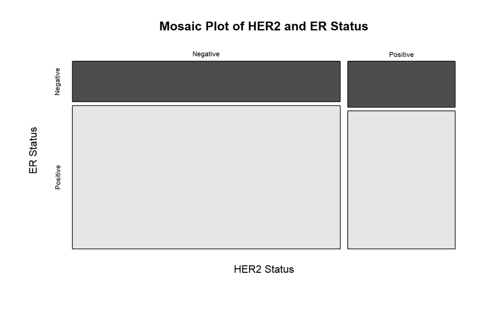

```r
# Create a mosaic plot to show the relationship between HER and ER
mosaicplot(status_table, main = "Mosaic Plot of HER2 and ER Status",
           xlab = "HER2 Status", ylab = "ER Status",
           color = TRUE)
```